# **Regression Project: Boston House Price Prediction**

### **3. Linearity of variables**

It states that the predictor variables must have a linear relation with the dependent variable.

To test the assumption, we'll plot residuals and the fitted values on a plot and ensure that residuals do not form a strong pattern. They should be randomly and uniformly scattered on the x-axis.

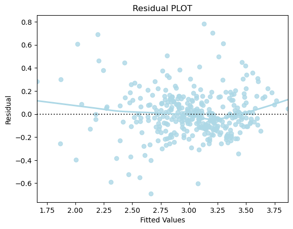

```python
# Predicted values
fitted = model2.fittedvalues

# sns.set_style("whitegrid")
sns.residplot(x = fitted, y = residuals, color = "lightblue", lowess = True)

plt.xlabel("Fitted Values")

plt.ylabel("Residual")

plt.title("Residual PLOT")

plt.show()
```

**Observations:**_****

There is no pattern in the residual vs fitted values plot. Hence, the corresponding assumption is satisfied.

### **4. Normality of error terms**

The residuals should be normally distributed.

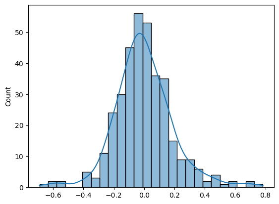

```python
# Plot histogram of residuals

# Write your code here

sns.histplot(residuals, kde = True)
```

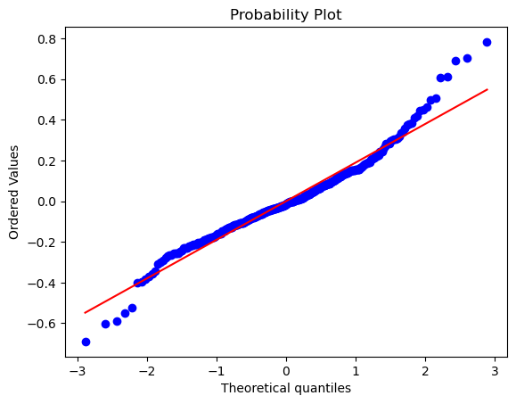

```python
# Plot q-q plot of residuals
import pylab

import scipy.stats as stats

stats.probplot(residuals, dist = "norm", plot = pylab)

plt.show()
```

**Observations:**_****

From the above plots, the residuals seem to follow a normal distribution. Hence, the corresponding assumption is satisfied. Now, we will check the model performance on the train and test dataset.

### **Check the performance of the model on the train and test data set**

### **Question 9:** Write your observations by comparing model performance of train and test dataset (4 Marks)

```python
# RMSE
def rmse(predictions, targets):
    return np.sqrt(((targets - predictions) ** 2).mean())


# MAPE
def mape(predictions, targets):
    return np.mean(np.abs((targets - predictions)) / targets) * 100


# MAE
def mae(predictions, targets):
    return np.mean(np.abs((targets - predictions)))


# Model Performance on test and train data
def model_pref(olsmodel, x_train, x_test):

    # In-sample Prediction
    y_pred_train = olsmodel.predict(x_train)
    y_observed_train = y_train

    # Prediction on test data
    y_pred_test = olsmodel.predict(x_test)
    y_observed_test = y_test

    print(
        pd.DataFrame(
            {
                "Data": ["Train", "Test"],
                "RMSE": [
                    rmse(y_pred_train, y_observed_train),
                    rmse(y_pred_test, y_observed_test),
                ],
                "MAE": [
                    mae(y_pred_train, y_observed_train),
                    mae(y_pred_test, y_observed_test),
                ],
                "MAPE": [
                    mape(y_pred_train, y_observed_train),
                    mape(y_pred_test, y_observed_test),
                ],
            }
        )
    )


# Checking model performance
model_pref(model2, X_train, X_test)
```

```
    Data      RMSE       MAE      MAPE
0  Train  0.192713  0.140133  4.864376
1   Test  0.191963  0.143914  5.004389
```

### **Apply cross validation to improve the model and evaluate it using different evaluation metrics**

```python
# Import the required function

from sklearn.model_selection import cross_val_score

# Build the regression model and cross-validate
linearregression = LinearRegression()

cv_Score11 = cross_val_score(linearregression, X_train, y_train, cv = 10)
cv_Score12 = cross_val_score(linearregression, X_train, y_train, cv = 10,
                             scoring = 'neg_mean_squared_error')
print("RSquared: %0.3f (+/- %0.3f)" % (cv_Score11.mean(), cv_Score11.std() * 2))
print("Mean Squared Error: %0.3f (+/- %0.3f)" % (-1*cv_Score12.mean(), cv_Score12.std() * 2))
```

```
RSquared: 0.733 (+/- 0.232)
Mean Squared Error: 0.041 (+/- 0.023)
```

### **Question 10:** Get model Coefficients in a pandas dataframe with column 'Feature' having all the features and column 'Coefs' with all the corresponding Coefs. (4 Marks)

```python
coef = pd.Series(index = X_train.columns, data = model2.params.values)
coefs = model2.params.values
coef_df = pd.DataFrame({'Feature': X_train.columns, 'Coefs': coefs})
coef_df
```

|  | Feature | Coefs |
| --- | --- | --- |
| 0 | const | 4.685598 |
| 1 | CRIM | -0.012888 |
| 2 | ZN | 0.001638 |
| 3 | INDUS | 0.003209 |
| 4 | CHAS | 0.102782 |
| 5 | NOX | -1.014130 |
| 6 | RM | 0.050859 |
| 7 | AGE | 0.000340 |
| 8 | DIS | -0.052310 |
| 9 | RAD | 0.015292 |
| 10 | TAX | -0.000546 |
| 11 | PTRATIO | -0.042743 |
| 12 | LSTAT | -0.029916 |

```python
# Let us write the equation of the fit

Equation = "log (Price) = "

print(Equation, end = '\t')

for i in range(len(coef)):
    print('(', coef[i], ') * ', coef.index[i], '+', end = ' ')
```

[output not shown]

**Note:** There might be slight variation in the coefficients depending on the library version you are using. There will be no deducting in marks for that as long as your observations are aligned with the output. In case, the coefficients vary too much, please make sure your code is correct.

### **Question 11:** Write the conclusions and business recommendations derived from the model. (10 Marks)

Conclusions

Business Recommendations

The problem at hand is to predict the housing prices of a town or a suburb based on the features of the locality provided to us. In the process, we need to identify the most important features affecting the price of the house.